# Tests {DMC21cent}

```r
library(DMC21cent)
```

# Lab Spaghetti Plot

This section illustrates the spaghetti plot for the parameters that all patients have the same unique value for `A1HI` (Analysis Range 1 Upper Limit).

Let’s determine which parameters have a unique A1HI and A1LO value for each patient throughout the specified visits.

```r
selected_visit = c("Baseline", "Week 2", "Week 4", "Week 6", "Week 8", "End of Treatment")
adlb <- adlbc

selected_params <- adlb %>%
  dplyr::filter(SAFFL == "Y") %>%
  dplyr::mutate(AVISIT = trimws(AVISIT, "l")) %>%
  dplyr::filter(AVISIT %in% selected_visit) %>%
  group_by(PARAM) %>%
  summarise(unique_A1HI = n_distinct(A1HI),
            unique_A1LO = n_distinct(A1LO)) %>%
  ungroup() %>%
  filter(unique_A1HI == 1,
         unique_A1LO == 1) %>%
  pull(PARAM)

selected_params %>% print()
```

```
#>  [1] "Alanine Aminotransferase (U/L) change from previous visit, relative to normal range"
#>  [2] "Albumin (g/L) change from previous visit, relative to normal range"
#>  [3] "Alkaline Phosphatase (U/L) change from previous visit, relative to normal range"
#>  [4] "Aspartate Aminotransferase (U/L) change from previous visit, relative to normal range"
#>  [5] "Bilirubin (umol/L)"
#>  [6] "Bilirubin (umol/L) change from previous visit, relative to normal range"
#>  [7] "Blood Urea Nitrogen (mmol/L)"
#>  [8] "Blood Urea Nitrogen (mmol/L) change from previous visit, relative to normal range"
#>  [9] "Calcium (mmol/L)"
#> [10] "Calcium (mmol/L) change from previous visit, relative to normal range"
#> [11] "Chloride (mmol/L)"
#> [12] "Chloride (mmol/L) change from previous visit, relative to normal range"
#> [13] "Cholesterol (mmol/L) change from previous visit, relative to normal range"
#> [14] "Creatine Kinase (U/L) change from previous visit, relative to normal range"
#> [15] "Creatinine (umol/L) change from previous visit, relative to normal range"
#> [16] "Gamma Glutamyl Transferase (U/L) change from previous visit, relative to normal range"
#> [17] "Glucose (mmol/L)"
#> [18] "Glucose (mmol/L) change from previous visit, relative to normal range"
#> [19] "Phosphate (mmol/L)"
#> [20] "Phosphate (mmol/L) change from previous visit, relative to normal range"
#> [21] "Potassium (mmol/L)"
#> [22] "Potassium (mmol/L) change from previous visit, relative to normal range"
#> [23] "Protein (g/L) change from previous visit, relative to normal range"
#> [24] "Sodium (mmol/L) change from previous visit, relative to normal range"
#> [25] "Urate (umol/L) change from previous visit, relative to normal range"
#> attr(,"label")
#> [1] "Parameter"
```

As follows, there is only one `PARAM` from the above list that has an `AVAL` (Analysis Value) larger than three times of the `A1HI` (Analysis Range 1 Upper Limit).

```r
adlb %>%
  filter(PARAM %in% selected_params) %>%
  filter(AVAL > 3*A1HI) %>%
  pull(PARAM) %>%
  unique() %>% print()
```

```
#> [1] "Bilirubin (umol/L)"
```

Here, we check the subjects who has `AVAL` (Analysis Value) values higher than `3*A1HI` (Analysis Range 1 Upper Limit)

## Part 1

### First test

```r
param_filter = "Bilirubin (umol/L)"
selected_visit = c("Baseline", "Week 2", "Week 4", "Week 6", "Week 8", "End of Treatment")
adlb <- adlbc



Data <- adlb %>%
  dplyr::select(USUBJID, PARAM, PARAMCD, AVISIT, TRTA, AVAL, A1HI, A1LO) %>%
  dplyr::mutate(AVISIT = trimws(AVISIT, "l")) %>%
  dplyr::filter(PARAM %in% param_filter) %>%
  dplyr::filter(AVISIT %in% selected_visit) %>%
  dplyr::mutate(AVISTTF = factor(AVISIT, levels = selected_visit)) %>%
  dplyr::filter(!is.na(AVAL))


selected_ids <- Data %>%
  dplyr::filter(AVAL > 3* A1HI) %>%
  pull(USUBJID)

Data %>%
  filter(USUBJID %in% selected_ids) %>%
  select(USUBJID, TRTA, AVISTTF, AVAL, A1HI, A1LO) %>%
  kableExtra::kable() %>%
    kableExtra::kable_styling(font_size = 14,
                              full_width = F,
                              #latex_options = "HOLD_position",
                              position = "center")
```

| USUBJID | TRTA | AVISTTF | AVAL | A1HI | A1LO |
| --- | --- | --- | --- | --- | --- |
| 01-705-1186 | Placebo | Baseline | 25.65 | 21 | 3 |
| 01-705-1186 | Placebo | Week 2 | 116.28 | 21 | 3 |
| 01-705-1186 | Placebo | Week 4 | 124.83 | 21 | 3 |
| 01-705-1186 | Placebo | End of Treatment | 124.83 | 21 | 3 |

We can confirm the selected patient is the one showed in the output of the following function.

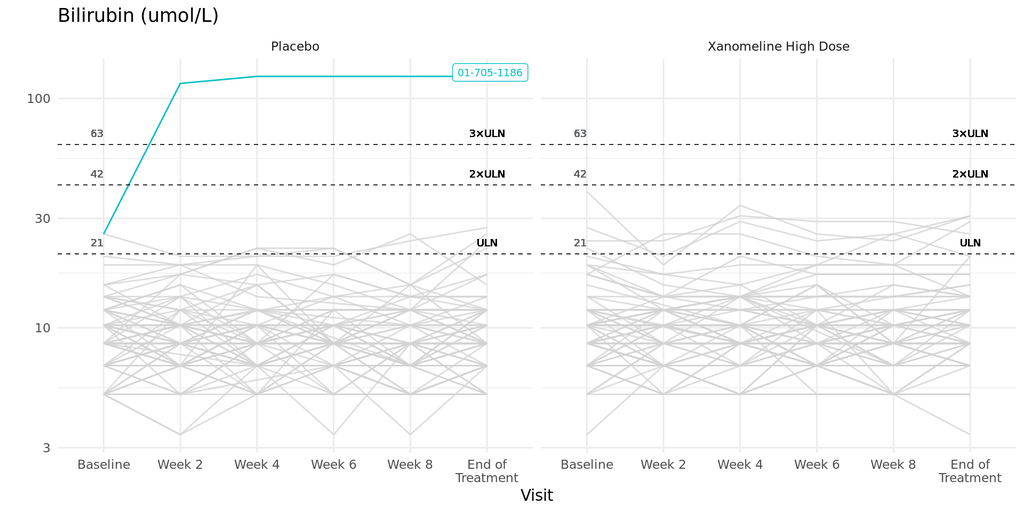

```r
lab_spaghetti(adlb = adlbc,
              param_filter = "Bilirubin (umol/L)",
              selected_visit = c("Baseline", "Week 2", "Week 4", "Week 6", "Week 8", "End of Treatment"))
```

## Part 2

### First test

For parameters for which no unique `A1HI` exists, we compare each patient’s `AVAL` to their own ’`A1HI` and pick those with at least one `AVAL` more than three times their own `A1HI`.

```r
param_filter = "Creatine Kinase (U/L)"
selected_visit = c("Baseline", "Week 2", "Week 4", "Week 6", "Week 8", "End of Treatment")
adlb <- adlbc



Data <- adlb %>%
  dplyr::select(USUBJID, PARAM, PARAMCD, AVISIT, TRTA, AVAL, A1HI, A1LO) %>%
  dplyr::mutate(AVISIT = trimws(AVISIT, "l")) %>%
  dplyr::filter(PARAM %in% param_filter) %>%
  dplyr::filter(AVISIT %in% selected_visit) %>%
  dplyr::mutate(AVISTTF = factor(AVISIT, levels = selected_visit)) %>%
  dplyr::filter(!is.na(AVAL))


selected_ids <- Data %>%
  dplyr::filter(AVAL > 3* A1HI) %>%
  pull(USUBJID)

Data %>%
  filter(USUBJID %in% selected_ids) %>%
  select(USUBJID, TRTA, AVISTTF, AVAL, A1HI, A1LO) %>%
  kableExtra::kable() %>%
    kableExtra::kable_styling(font_size = 14,
                              full_width = F,
                              #latex_options = "HOLD_position",
                              position = "center")
```

| USUBJID | TRTA | AVISTTF | AVAL | A1HI | A1LO |
| --- | --- | --- | --- | --- | --- |
| 01-701-1302 | Xanomeline High Dose | Baseline | 444 | 198 | 22 |
| 01-701-1302 | Xanomeline High Dose | Week 2 | 100 | 198 | 22 |
| 01-701-1302 | Xanomeline High Dose | Week 4 | 123 | 198 | 22 |
| 01-701-1302 | Xanomeline High Dose | Week 6 | 1860 | 198 | 22 |
| 01-701-1302 | Xanomeline High Dose | Week 8 | 145 | 198 | 22 |
| 01-701-1302 | Xanomeline High Dose | End of Treatment | 112 | 198 | 22 |
| 01-701-1345 | Placebo | Baseline | 142 | 169 | 21 |
| 01-701-1345 | Placebo | Week 2 | 99 | 169 | 21 |
| 01-701-1345 | Placebo | Week 4 | 140 | 169 | 21 |
| 01-701-1345 | Placebo | Week 6 | 134 | 169 | 21 |
| 01-701-1345 | Placebo | Week 8 | 132 | 169 | 21 |
| 01-701-1345 | Placebo | End of Treatment | 1556 | 169 | 21 |
| 01-707-1206 | Placebo | Baseline | 140 | 198 | 22 |
| 01-707-1206 | Placebo | Week 2 | 134 | 198 | 22 |
| 01-707-1206 | Placebo | Week 4 | 1125 | 198 | 22 |
| 01-707-1206 | Placebo | Week 6 | 112 | 198 | 22 |
| 01-707-1206 | Placebo | Week 8 | 110 | 198 | 22 |
| 01-707-1206 | Placebo | End of Treatment | 210 | 198 | 22 |
| 02-708-1342 | Placebo | Baseline | 115 | 169 | 21 |
| 02-708-1342 | Placebo | Week 2 | 536 | 169 | 21 |
| 02-708-1342 | Placebo | Week 4 | 132 | 169 | 21 |
| 02-708-1342 | Placebo | Week 6 | 151 | 169 | 21 |
| 02-708-1342 | Placebo | Week 8 | 199 | 169 | 21 |
| 02-708-1342 | Placebo | End of Treatment | 174 | 169 | 21 |

Here, we can confirm that the patients chosen are identical to those generated by the following plot.

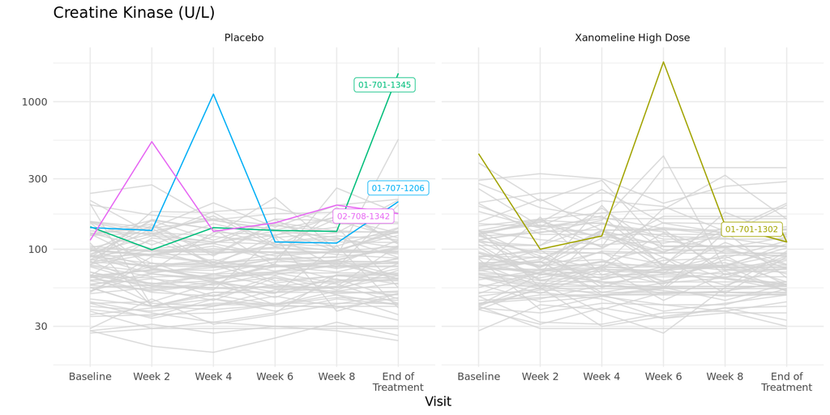

```r
lab_spaghetti(adlb = adlbc,
              param_filter = "Creatine Kinase (U/L)",
              axis_tick_size = 8,
              x_axis_wrap = 6,
              selected_visit = c("Baseline", "Week 2", "Week 4", "Week 6", "Week 8", "End of Treatment"))
```

### Second test

```r
param_filter = "Alanine Aminotransferase (U/L)"
selected_visit = c("Baseline", "Week 2", "Week 4", "Week 6", "Week 8", "End of Treatment")
adlb <- adlbc



Data <- adlb %>%
  dplyr::select(USUBJID, PARAM, PARAMCD, AVISIT, TRTA, AVAL, A1HI, A1LO) %>%
  dplyr::mutate(AVISIT = trimws(AVISIT, "l")) %>%
  dplyr::filter(PARAM %in% param_filter) %>%
  dplyr::filter(AVISIT %in% selected_visit) %>%
  dplyr::mutate(AVISTTF = factor(AVISIT, levels = selected_visit)) %>%
  dplyr::filter(!is.na(AVAL))


selected_ids <- Data %>%
  dplyr::filter(AVAL > 3* A1HI) %>%
  pull(USUBJID)

Data %>%
  filter(USUBJID %in% selected_ids) %>%
  select(USUBJID, TRTA, AVISTTF, AVAL, A1HI, A1LO) %>%
  kableExtra::kable() %>%
    kableExtra::kable_styling(font_size = 14,
                              full_width = F,
                              #latex_options = "HOLD_position",
                              position = "center")
```

| USUBJID | TRTA | AVISTTF | AVAL | A1HI | A1LO |
| --- | --- | --- | --- | --- | --- |
| 01-705-1186 | Placebo | Baseline | 50 | 32 | 6 |
| 01-705-1186 | Placebo | Week 2 | 104 | 32 | 6 |
| 01-705-1186 | Placebo | Week 4 | 107 | 32 | 6 |
| 01-705-1186 | Placebo | End of Treatment | 107 | 32 | 6 |
| 01-705-1310 | Xanomeline High Dose | Baseline | 10 | 32 | 6 |
| 01-705-1310 | Xanomeline High Dose | Week 2 | 13 | 32 | 6 |
| 01-705-1310 | Xanomeline High Dose | Week 4 | 15 | 32 | 6 |
| 01-705-1310 | Xanomeline High Dose | Week 6 | 20 | 32 | 6 |
| 01-705-1310 | Xanomeline High Dose | Week 8 | 129 | 32 | 6 |
| 01-705-1310 | Xanomeline High Dose | End of Treatment | 10 | 32 | 6 |
| 02-708-1286 | Placebo | Baseline | 13 | 32 | 6 |
| 02-708-1286 | Placebo | Week 2 | 12 | 32 | 6 |
| 02-708-1286 | Placebo | Week 6 | 14 | 32 | 6 |
| 02-708-1286 | Placebo | Week 8 | 12 | 32 | 6 |
| 02-708-1286 | Placebo | End of Treatment | 124 | 32 | 6 |

Here, we can confirm that the patients chosen are identical to those generated by the following plot.

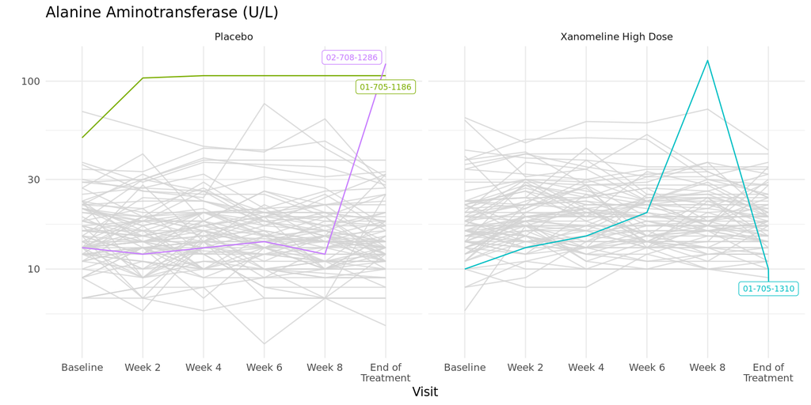

```r
lab_spaghetti(adlb = adlbc,
              param_filter = "Alanine Aminotransferase (U/L)",
              axis_tick_size = 8,
              x_axis_wrap = 6,
              selected_visit = c("Baseline", "Week 2", "Week 4", "Week 6", "Week 8", "End of Treatment"))
```